# This Tutorial cover the basics of Opencv, Numpy and Matplotlib modules

### Credits

1.[Opencv Official Documentation](https://opencv-python-tutroals.readthedocs.io/en/latest/py_tutorials/py_tutorials.html)

2.[Numpy Tutorial](https://www.tutorialspoint.com/numpy/index.htm)

3.[Matplotlib Tutorial](https://matplotlib.org/3.1.1/tutorials/index.html)

## 1 Opencv Basics

### 1.1 How to load a video file

```python
import cv2

source=cv2.VideoCapture('Samples 1/sample_video.MP4')
#loading the video source (a video file from your pc)

while(True):

    ret,img=source.read()
    #reading single frame from the video source (img-frame read, ret- 0 when source is not available, 1 when source is available )

    if(ret==True):
    #checking whether the video source is available

        cv2.imshow('LIVE',img)
        #showing the "img" in the window "LIVE"

        key=cv2.waitKey(1)
        #1ms delay until a key is pressed

        if(key==27):
        #if a key is pressed, checking whether the pressed key is 'esc'

            break
            #if then break the loop

cv2.destroyAllWindows()
#destroying all teh active windows by opencv
source.release()
#releasing/closing the video source
```

cv2.waitKey() is a keyboard binding function. Its argument is the time in milliseconds. The function waits for specified milliseconds for any keyboard event. If you press any key in that time, the program continues. If 0 is passed, it waits indefinitely for a key stroke. It can also be set to detect specific key strokes like, if key a is pressed etc which we will discuss below.

read more about `cv2.waitKey()` function

1. [Keyboard ASCII values](https://progtpoint.blogspot.com/2017/06/key-board-ascii-key-code.html)
2. [OpenCV official Documentation](https://opencv-python-tutroals.readthedocs.io/en/latest/py_tutorials/py_gui/py_image_display/py_image_display.html#display-image)

### 1.2 Color Conversion

```python
img1=cv2.imread('Samples 1/flower.jpg',0)
img2=cv2.imread('Samples 1/flower.jpg',1)
img3=cv2.imread('Samples 1/flower.jpg',-1)

cv2.imshow('IMG1',img1)
cv2.imshow('IMG2',img2)
cv2.imshow('IMG3',img3)

cv2.waitKey(0)
cv2.destroyAllWindows()
#press any key to destroy all windows
```

Use the function cv2.imread() to read an image. The image should be in the working directory or a full path of image should be given.

Second argument is a flag which specifies the way image should be read.

1. cv2.IMREAD_COLOR : Loads a color image. Any transparency of image will be neglected. It is the default flag.
2. cv2.IMREAD_GRAYSCALE : Loads image in grayscale mode
3. cv2.IMREAD_UNCHANGED : Loads image as such including alpha (the transparency) channel Note

Instead of these three flags, you can simply pass integers 1, 0 or -1 respectively

### 1.3 Changing Colorspaces

```python
img=cv2.imread('Samples 1/flower.jpg')

gray=cv2.cvtColor(img,cv2.COLOR_BGR2GRAY)
hsv=cv2.cvtColor(img,cv2.COLOR_BGR2HSV)

cv2.imshow('IMG',img)
cv2.imshow('GRAY',gray)
cv2.imshow('HSV',hsv)

cv2.waitKey(0)
cv2.destroyAllWindows()
```

There are more than 150 color-space conversion methods available in OpenCV. But we will look into only two which are most widely used ones, BGR \leftrightarrow Gray and BGR \leftrightarrow HSV.

For color conversion, we use the function cv2.cvtColor(input_image, flag) where flag determines the type of conversion.

For BGR \rightarrow Gray conversion we use the flags cv2.COLOR_BGR2GRAY. Similarly for BGR \rightarrow HSV, we use the flag cv2.COLOR_BGR2HSV. To get other flags, just run following commands in your Python terminal :

```
>>> import cv2
>>> flags = [i for i in dir(cv2) if i.startswith('COLOR_')]
>>> print flags
```

Read more about colorspaces

1. [Tutorialspoint Digital Image Processing](https://www.tutorialspoint.com/dip/grayscale_to_rgb_conversion.htm)
2. [HSV colorspace](https://en.wikipedia.org/wiki/HSL_and_HSV)

### 1.4 Image Thresholding

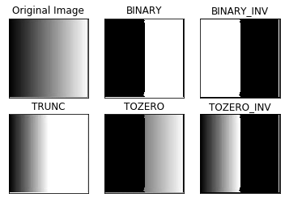

```python
import cv2
import numpy as np
from matplotlib import pyplot as plt

img = cv2.imread('Samples 1/threshold.jpg',0)
ret,thresh1 = cv2.threshold(img,127,255,cv2.THRESH_BINARY)
ret,thresh2 = cv2.threshold(img,127,255,cv2.THRESH_BINARY_INV)
ret,thresh3 = cv2.threshold(img,127,255,cv2.THRESH_TRUNC)
ret,thresh4 = cv2.threshold(img,127,255,cv2.THRESH_TOZERO)
ret,thresh5 = cv2.threshold(img,127,255,cv2.THRESH_TOZERO_INV)

titles = ['Original Image','BINARY','BINARY_INV','TRUNC','TOZERO','TOZERO_INV']
images = [img, thresh1, thresh2, thresh3, thresh4, thresh5]

for i in range(6):
    plt.subplot(2,3,i+1),
    plt.imshow(images[i],'gray')
    plt.title(titles[i])
    plt.xticks([]),plt.yticks([])

plt.show()
```

Here, the matter is straight forward. If pixel value is greater than a threshold value, it is assigned one value (may be white), else it is assigned another value (may be black). The function used is cv2.threshold. First argument is the source image, which should be a grayscale image. Second argument is the threshold value which is used to classify the pixel values. Third argument is the maxVal which represents the value to be given if pixel value is more than (sometimes less than) the threshold value. OpenCV provides different styles of thresholding and it is decided by the fourth parameter of the function. Different types are:

| cv2.THRESH_BINARY |
| --- |
| cv2.THRESH_BINARY_INV |
| cv2.THRESH_TRUNCV |
| cv2.THRESH_TOZEROV |
| cv2.THRESH_TOZERO_INV |

### 1.5 Imshow using matplotlib

Matplotlib is a plotting library for Python which gives you wide variety of plotting methods. You will see them in coming articles. Here, you will learn how to display image with Matplotlib. You can zoom images, save it etc using Matplotlib.

```python
import numpy as np
import cv2
from matplotlib import pyplot as plt

img = cv2.imread('Samples 1/flower.jpg',0)
plt.imshow(img, cmap = 'gray')
#plt.xticks([]), plt.yticks([])  #uncomment to to hide tick values on X and Y axis
plt.show()
```

[output not shown]

### 1.6 Wrting and Saving Images

Use the function cv2.imwrite() to save an image. First argument is the file name, second argument is the image you want to save.

```python
cv2.imwrite('flower.png',img)
```